# 1. Introdução

### 3.3.7 Internações por trauma e precipitação extrema por triênio

#### Figura 23: Internações por trauma e dias com chuva extrema por triênio

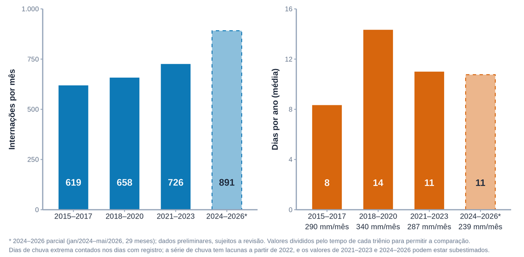

Fonte: Elaborado pelo CISC Belém, através dos dados do SIH; do INMET. Período das internações: janeiro de 2015 a maio de 2026; último triênio parcial.

As médias mensais de internações classificadas como trauma (S00–T98) aumentaram entre os períodos: 619 em 2015–2017, 658 em 2018–2020, 726 em 2021–2023 e 891 entre janeiro de 2024 e maio de 2026. O indicador de dias com precipitação ≥ 50 mm apresentou valores de aproximadamente 8, 14, 11 e 11 dias/ano, respectivamente. O maior valor desse indicador ocorreu em 2018–2020, enquanto a maior média de internações ocorreu no período mais recente. Entretanto, as lacunas de precipitação a partir de 2022 podem subestimar as contagens, e o último período é parcial. A comparação descritiva desses quatro períodos não permite concluir se existe associação entre chuva extrema e internações por trauma.

### 3.3.8 Síndromes gastrointestinais após chuvas ou inundações

#### Figura 24: Síndromes gastrointestinais e precipitação extrema (controle semanal)

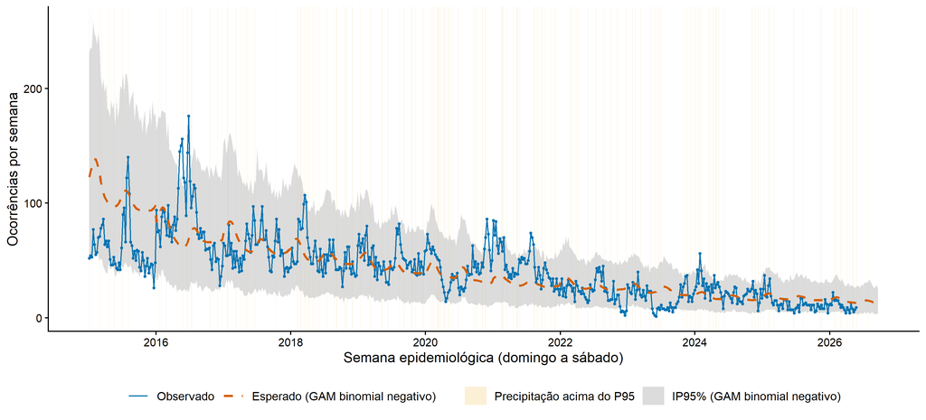

Fonte: Elaborado pelo CISC Belém, através dos dados do SIH; do INMET. Período: 04/01/2015 a 30/05/2026.

De 04/01/2015 a 30/05/2026, em relação às internações por síndromes gastrointestinais (SIH/SUS), foram observadas 25.069 internações frente a 26.112,1 esperadas em 595 semanas. O saldo foi de -1.043,1 AIH de internação, com 24 semanas acima do IP95%. A comparação abrange todas as semanas válidas, não apenas as dos episódios climáticos.

**Nota:** exclusões de COVID-19 conforme a seção 2.2; série até maio de 2026. A queda de abril e maio de 2020 é compatível com a suspensão de cirurgias eletivas e com a redução de acidentes no período de restrições.

#### Figura 25: CCF entre a série assistencial e a chuva acumulada antecedente

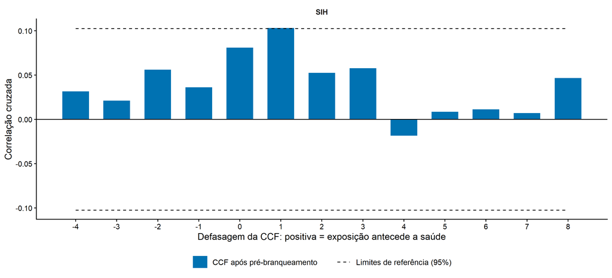

Fonte: Elaborado pelo CISC Belém, através dos dados do SIH; do INMET. Período: 11/01/2015 a 23/01/2022.

**Nota:** a CCF usa o maior bloco contínuo de semanas com chuva e desfecho válidos, que termina em janeiro de 2022; depois disso a série semanal pareada tem lacunas.

### 3.3.9 Leptospirose após precipitação extrema ou inundação

#### Figura 26: Diagrama de controle mensal da leptospirose no SIM

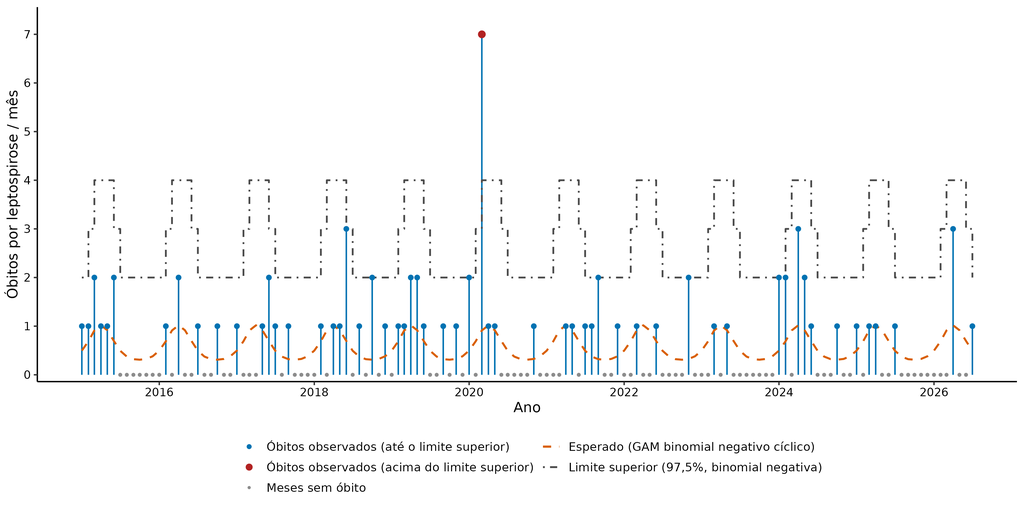

Fonte: Elaborado pelo CISC Belém, através dos dados do SIM. Período: 01/2015 a 07/2026 (meses completos).

O SIM registrou 82 óbitos por leptospirose em 139 meses completos (média de 0,6 por mês). O esperado acompanha o período chuvoso, de 1,0 óbito por mês em abril a 0,3 em outubro. Apenas março de 2020 superou o limite superior (7 óbitos; limite de 4).

Nota: GAM binomial negativo com spline cíclica do mês, ajustado nos meses completos, incluindo 2020 e 2021; o limite superior é o quantil de 97,5% da distribuição ajustada. Meses incompletos não entram. O excesso de março de 2020 coincide com o início da pandemia, período de atraso e reclassificação de causas de óbito.

#### Figura 27: CCF entre chuva e leptospirose após pré-branqueamento AR(p) de Box-Jenkins

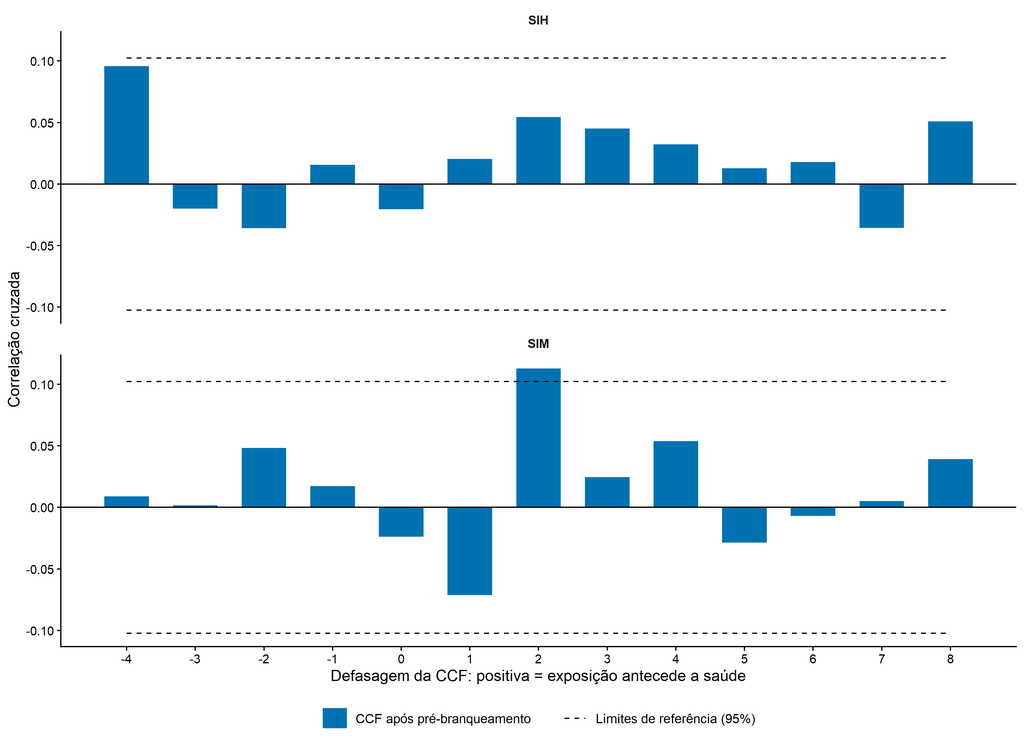

Fonte: Elaborado pelo CISC Belém, através dos dados do SIH; do SIM; do INMET. Período: SIH 04/01/2015 a 16/01/2022; SIM 04/01/2015 a 16/01/2022.

As maiores correlações em módulo foram: SIH, r = +0,096 (chuva 4 semanas depois); SIM, r = +0,113 (chuva 2 semanas antes). Há coeficientes acima dos limites exploratórios.

**Nota:** a CCF usa o maior bloco contínuo de semanas com chuva e desfecho válidos, que termina em janeiro de 2022; depois disso a série semanal pareada tem lacunas.

## 3.4 Seção 4: Identificação de sub-regiões ou áreas prioritárias

### 3.4.1 Mapas das variáveis territoriais

O mapa apresenta os contrastes entre os Distritos Administrativos de Belém pelo Índice de Vulnerabilidade Territorial (IVT), cuja construção e robustez estão descritas na seção 2.3.

#### Figura 28: Índice de Vulnerabilidade Territorial (IVT) por Distrito Administrativo

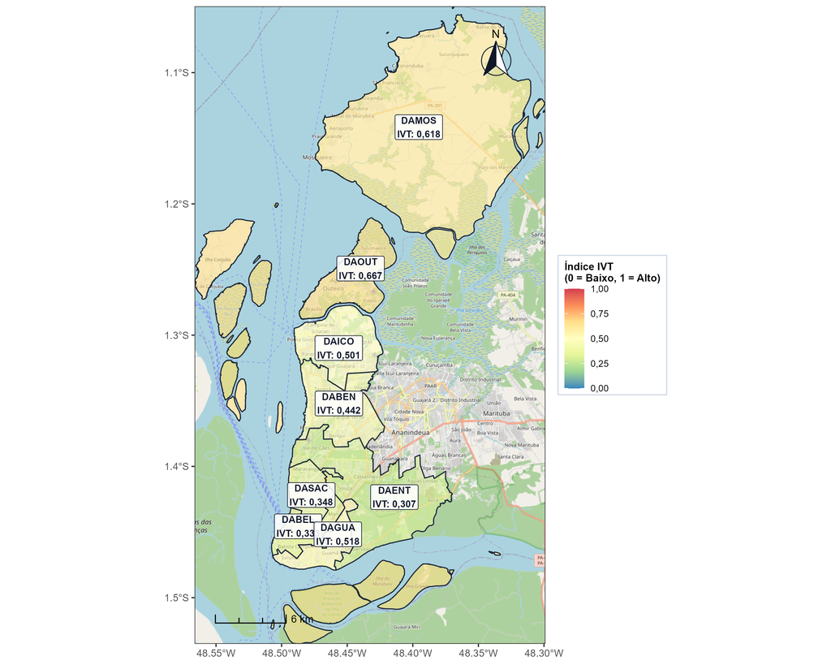

Fonte: Elaborado pelo CISC Belém, através dos dados do IVS/IPEA, da rede de sensores de temperatura (PurpleAir e INMET) e da CODEM. Mapa de fundo: © OpenStreetMap contributors.

Pelo modelo principal (pesos iguais), os distritos mais vulneráveis foram DAOUT (0,667), DAMOS (0,618), DAGUA (0,518) e os menos vulneráveis, DASAC (0,348), DABEL (0,333), DAENT (0,307). No cenário Clima (20/20/60), o τ de Kendall foi 0,214 (60,7% dos pares mantêm a ordem; 5 distritos mudam de posição). Pelo critério τ ≥ 0,70, o ranking depende dos pesos escolhidos. Apenas DAMOS permanece entre os três mais vulneráveis em todos os cenários de pesos.

Nota: a dimensão climática usa a temperatura dos sensores mais próximos de cada distrito no momento da extração (02/10/2026), com apenas 4 valores distintos de temperatura entre os 8 distritos; não é média climatológica. O IVS das UDHs tem como base o Censo 2010. Com 8 unidades, a padronização mín-máx amplia diferenças pequenas entre distritos.

Quadro 2: Ranking do Índice de Vulnerabilidade Territorial (IVT) por Distrito Administrativo

| Posição | Sigla | IVS Renda e Trabalho | % sem água e esgoto adequados | Temperatura (°C) | IVT principal |
| --- | --- | --- | --- | --- | --- |
| 1 | DAOUT | 0,443 | 18,0 | 29,4 | 0,667 |
| 2 | DAMOS | 0,363 | 13,6 | 30,0 | 0,618 |
| 3 | DAGUA | 0,347 | 3,1 | 30,6 | 0,518 |
| 4 | DAICO | 0,352 | 8,1 | 30,0 | 0,501 |
| 5 | DABEN | 0,337 | 5,8 | 30,0 | 0,442 |
| 6 | DASAC | 0,327 | 1,4 | 30,0 | 0,348 |
| 7 | DABEL | 0,119 | 0,5 | 31,1 | 0,333 |
| 8 | DAENT | 0,304 | 6,7 | 29,4 | 0,307 |

Fonte: Elaborado pelo CISC Belém, através dos dados do IVS/IPEA, dos sensores de temperatura e da CODEM.

### 3.4.2 Vulnerabilidade territorial e áreas prioritárias

Na escala de Distrito Administrativo, o IVT é confrontado com os registros cardiovasculares regulados no SISREG.

#### Figura 29: IVT e registros cardiovasculares regulados (SISREG) por Distrito Administrativo

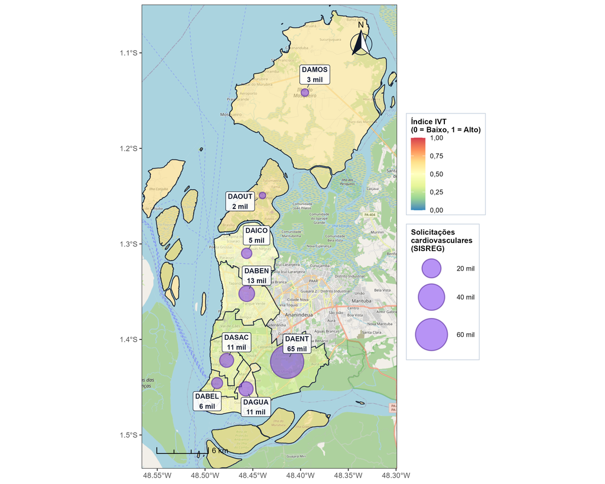

Fonte: Elaborado pelo CISC Belém, através dos dados do SISREG (DVS/SESMA Belém), do IBGE (Censo 2022) e da CODEM. Mapa de fundo: © OpenStreetMap contributors.

Foram 116.209 registros regulados com CID-10 I00 a I99 ligados a distritos, com taxa bruta acumulada de 902,7 por 10 mil habitantes. Entre IVT e taxa, τ de Kendall = 0,143 (p exato = 0,720) e ρ de Spearman = 0,167 (p exato = 0,703): não há evidência de associação monotônica entre IVT e taxa com 8 distritos. Sem o setor censitário do bairro Val-de-Cães (DAENT) que concentra esses registros, a taxa municipal cai para 448,0 por 10 mil e a associação passa a τ = 0,500 (p exato = 0,109) e ρ = 0,714 (p exato = 0,058).

Nota: o SISREG registra solicitações de regulação, não internações SIH/AIH; a taxa é bruta (sem padronização por idade) e acumulada em todo o período da base, e a análise é ecológica (n = 8). O valor do DAENT reflete a concentração de 58.530 registros (50,4% do município) em um único setor censitário do bairro Val-de-Cães, padrão compatível com endereço-padrão ou georreferenciamento pelo estabelecimento, e não pela residência; esse valor não deve ser lido como risco do distrito.

Quadro 3: Correlação de postos entre o IVT e a taxa de solicitações cardiovasculares (n = 8 distritos)

| Medida | Coeficiente | p-valor exato | Leitura |
| --- | --- | --- | --- |
| τ de Kendall (principal) | 0,143 | 0,720 | 57% dos pares de distritos na mesma ordem (IVT e taxa) |
| ρ de Spearman (complementar) | 0,167 | 0,703 | Correlação entre as posições no ranking |
| τ de Kendall, sem o setor de Val-de-Cães | 0,500 | 0,109 | Análise de sensibilidade |
| ρ de Spearman, sem o setor de Val-de-Cães | 0,714 | 0,058 | Análise de sensibilidade |

Fonte: Elaborado pelo CISC Belém.

## 3.5 Seção 5: Gatilhos para alerta

Os boxplots comparam os registros semanais antes da definição de gatilhos operacionais, mantendo SIH e SIM separados.

#### Figura 30: Distribuições semanais do SIH e do SIM antes da validação de gatilhos

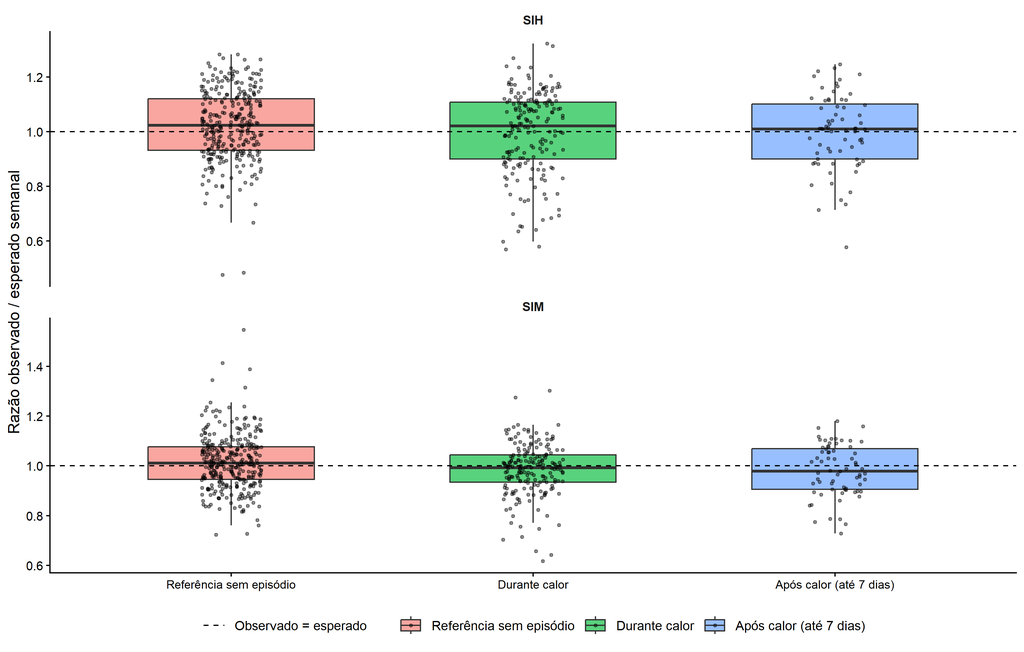

Fonte: Elaborado pelo CISC Belém, através dos dados do SIH; do SIM; do INMET. Período: 11/01/2015 a 16/08/2026.

As medianas da razão observado/esperado foram: SIH: sem episódio 1,02 (n=310), durante 1,02 (n=187), após 1,01 (n=68); SIM: sem episódio 1,01 (n=321), durante 0,99 (n=187), após 0,98 (n=68). Valores acima de 1 indicam mais registros que o esperado; a comparação não define alertas oficiais. Medianas próximas de 1 nos três grupos indicam que, no conjunto do período, não há deslocamento sistemático de óbitos ou internações nas semanas de calor.

**Nota:** exclusões de COVID-19 conforme a seção 2.2.

#### Matriz Operacional de Gatilhos de Alerta para Calor Extremo

Nível de Alerta e Status

Janela Temporal (Oportunidade)

Gatilhos Meteorológicos e Bioclimáticos  
(INMET A201/82191)

Gatilhos Assistenciais e Epidemiológicos  
(e-SUS APS, RUE, SAMU e SIM)

Territórios Prioritários Acionados  
(Diagnóstico IVT e Densidade)

Ações Prioritárias Vinculadas  
(Protótipo de Ações CISC Belém)

Responsáveis pelo Acionamento

NÍVEL 1: VERDE  
*Normalidade*  
(Condição Normal)

**Contínuo**  
(Rotina diária e semanal)

- Tmax < P90 sazonal (climatologia 1991–2020)
- Índice de Calor (IC) < 38 °C
- Sem noites quentes (Tmin noturna < P90 de 24,5 °C)
- Anomalia de temperatura entre −0,5 e +0,5 °C
- Atendimentos na APS e UPAs dentro da média sazonal
- Razão observado/esperado (SIM e SIH) próxima de 1,00 e diagrama de controle semanal dentro do IP95%

Os 8 Distritos Administrativos em vigilância ambiental contínua.

- Monitoramento diário pelo CISC (Ação 1)
- APS: cadastro atualizado de idosos (≥ 60 anos) e pessoas com DCNT (Ação 2)
- Rotina do pipeline CISC-Analytics e do georreferenciamento (Ação 4)

CISC Belém e DVS/SESMA.

NÍVEL 2: AMARELO  
*Atenção*  
(Risco Potencial)

**D-3 a D-1**  
(Antecedência de 48h a 72h)

- Previsão de Tmax ≥ P90 sazonal por 1 a 2 dias
- 1 a 2 noites previstas com Tmin noturna ≥ P90 (24,5 °C)
- IC máximo previsto de 38 a < 41 °C
- Aumento discreto de queixas de desidratação, fadiga e mal-estar na APS e UPAs
- Chamados do SAMU por tontura/síncope ainda dentro do limite de controle
- Sinal precoce, antes da consolidação dos óbitos no SIM

Distritos insulares (DAMOS e DAOUT) e de adensamento periférico (DAGUA e DAICO).

- Boletim extraordinário de pré-alerta do CISC à SESMA, SAMU e Defesa Civil (Ação 1)
- Notificação às UBS de DAMOS, DAOUT e DAGUA para checagem de estoques de soro e sais de reidratação (Ação 2)
- Alerta preventivo à SECON (feiras) e à SEMEC (escolas) (Ação 3)

CISC Belém, Gabinete SESMA, Defesa Civil (SEMDEC), SAMU 192 e Distritos Sanitários.

NÍVEL 3: LARANJA  
*Alerta*  
(Calor Persistente)

**D0 a D+2**  
(Início da onda de calor e persistência)

- Onda de calor (prevista ou em curso): ≥ 3 dias com Tmax ≥ P90 sazonal
- ≥ 3 noites consecutivas com Tmin noturna ≥ P90 (24,5 °C)
- IC máximo diário de 41 a < 45 °C
- Aumento de 10% a 20% nas urgências (crise hipertensiva, arritmias, insuficiência renal e diabetes descompensado) em UPAs e UBS
- Mais atendimentos na APS por síncope e exaustão pelo calor
- Mais chamados do SAMU por colapso circulatório em idosos

FOCO PRIORITÁRIO MÁXIMO:  
1. DAMOS (Mosqueiro, IVT 0,618) e DAOUT (Outeiro, IVT 0,667): isolamento e 14–18% sem água e esgoto adequados;  
2. DAGUA (Guamá, IVT 0,518): densidade extrema (19.421 hab/km²);  
3. Ver-o-Peso e feiras livres (comércio informal).

- Monitoramento em tempo real (CISC) e reuniões diárias com a Defesa Civil (Ação 1)
- Salas de Hidratação Rápida nas UBS/UPAs prioritárias; busca ativa domiciliar de idosos e acamados (ACS); revisão médica de diuréticos e anti-hipertensivos (Ação 2)
- Estações de hidratação no Ver-o-Peso e feiras; sem atividades físicas ao ar livre nas escolas municipais das 10h às 16h (Ação 3)

Gabinete SESMA, DAB e DAE (UPAs), Distritos Sanitários, CISC Belém, Defesa Civil, SECON e SEMEC.

NÍVEL 4: VERMELHO  
*Emergência*  
(Calor Extremo e Severo)

**D0 a D+4**  
(Episódio extremo ou colapso assistencial)

- ≥ 4 dias consecutivos com Tmax acima do P90 sazonal
- IC ≥ 45 °C (recorde de Belém: 45,8 °C)
- ≥ 3 noites consecutivas acima do P95 sazonal noturno
- Anomalia da Tmax diária > +2,5 °C
- Sobrecarga crítica das salas de estabilização das UPAs e prontos-socorros
- Despachos do SAMU por parada cardiorrespiratória e choque térmico acima do IP95%
- Mortalidade geral e cardiovascular acima do IP95% no SIM por 2 semanas consecutivas

Mobilização em todo o município, com reforço em:

- bairros periféricos de alta vulnerabilidade social e baixa cobertura de saneamento;
- população de rua e trabalhadores informais ao sol (Ver-o-Peso, feiras e portos);
- comunidades isoladas e ribeirinhas de Mosqueiro e Outeiro.
- Convocação imediata do Comitê de Crise Climática (Ação 1)
- Horário estendido nas UBS de DAMOS, DAOUT e DAGUA; leitos de hidratação nas UPAs (Ação 2)
- Socorro térmico: água e refúgios climáticos para população de rua e trabalhadores (Ação 3)
- Sala de Situação 24h com indicadores de sobrecarga (Ação 4)

Comitê de Crise Climática, Prefeito, Secretário Municipal de Saúde, Defesa Civil, SAMU 192 e Força-Tarefa Intersetorial.

Fonte: Elaborado pelo CISC Belém com base na Matriz Operacional de Gatilhos de Alerta para Calor Extremo, integrando dados do INMET (estações A201 e 82191), indicadores do e-SUS APS, RUE, SAMU 192 e SIM, e o Índice de Vulnerabilidade Territorial (IVT) dos 8 Distritos Administrativos de Belém.

## 3.6 Seção 6: Protótipo de ações prioritárias

#### Protótipo de ações integrado aos resultados atualizados

**CISC / Localidade:** CISC Belém/PA

Nome da Ação

Descrição da Ação

Resultados Esperados

Temporalidade

Áreas Técnicas Envolvidas

Monitoramento

Ação 1: Implantação do Sistema Municipal de Vigilância e Gatilhos de Alerta Precoce para Calor e Noites Quentes (SIS-Alerta Belém)  
*[AdaptaSUS: 1. Vigilância em Saúde]*

**Território:** Município de Belém (8 Distritos Administrativos).  
**População e Agravos:** População geral, prevenindo picos de mortalidade geral e cardiovascular fora do padrão esperado (IP95%).  
**Gatilhos Escalonados:**

- *Amarelo:* Previsão de 1–2 dias com Tmax ≥ P90 ou IC de 38 a < 41 °C (disparo de boletim preventivo);
- *Laranja:* Previsão de ≥3 dias com Tmax ≥ P90, ≥3 noites quentes (Tmin ≥ 24,5 °C) ou IC de 41 a < 45 °C (mobilização das UBS e ACS);
- *Vermelho:* ≥4 dias > P90, noites > P95 ou IC ≥ 45 °C (recorde de 45,8 °C; ativação de comitê de crise e socorro pleno).

**Atividades:**

1. Integração contínua dos dados das estações INMET (82191 e A201) ao painel do CISC;
2. Emissão de Boletins de Alerta Precoce com antecedência de 48h a 72h à SESMA, SAMU e Defesa Civil;
3. Vigilância assistencial sentinela diária para detecção de picos nas portas de entrada.
1. Sistema de alerta precoce operando formalmente em Belém de forma ininterrupta;
2. Antecipação da resposta das redes de saúde e defesa civil em no mínimo 48 horas antes da onda de calor;
3. Série de episódios de calor e de desfechos em saúde organizada para calibrar os limiares pelo risco à saúde.

Curto prazo (até 1 ano)

**SESMA Belém:**  
Depto. Vigilância em Saúde (DVS/DVE e Vigil. Ambiental);  
CISC Belém;  
Coordenação Geral do SAMU 192;  
Defesa Civil de Belém (SEMDEC);  
INMET (2ª DISME).

**Indicador 1:** Índice de Oportunidade dos Alertas (% emitidos com ≥ 48h de antecedência). Meta: ≥ 90% dos episódios no 1º ano.  
**Indicador 2:** Acurácia preditiva dos gatilhos locais. Meta: ≥ 85% após calibragem semestral.  
**Indicador 3:** Tempo de difusão do alerta para UPAs, UBS e SAMU. Meta: < 2h pós-confirmação meteorológica.  
*Acompanhamento: Painel diário do CISC e relatório mensal à direção da SESMA.*

Ação 2: Rede Municipal de Hidratação e Proteção Clínica de Grupos Vulneráveis ao Calor em Belém  
*[AdaptaSUS: 2. Atenção à Saúde]*

**Território e Público:** DAMOS (Mosqueiro), DAOUT (Outeiro), DAGUA (Guamá) e DAICO (Icoaraci); idosos (≥60 anos), portadores de DCNT e acamados.  
**Agravos:** Exaustão térmica (CID-10 T67), descompensação de HAS, IC e DM2, e mortalidade cardiovascular acima do IP95%.  
**Gatilho Operacional:** Nível Amarelo (preparação) e Níveis Laranja e Vermelho da Matriz de Gatilhos (IC ≥ 41 °C ou ≥ 3 dias consecutivos com Tmax ≥ P90).  
**Atividades:**

1. Salas de Hidratação Rápida climatizadas nas UBS/UPAs de DAMOS, DAOUT, DAGUA e DAICO;
2. Busca ativa domiciliar por ACS de idosos, acamados e pacientes com DCNT nos dias de alerta;
3. Protocolo médico de revisão de dosagem de diuréticos e anti-hipertensivos em ondas de calor;
4. Leitos de hidratação de contingência ativados nas UPAs em Nível Vermelho.
1. Rede de UBS/UPAs operando com salas de hidratação em 100% dos episódios de alerta nos distritos prioritários;
2. Fluxo de acompanhamento de idosos e pessoas com DCNT nos dias de alerta implantado nas UBS dos distritos prioritários (DAOUT, DAMOS e DAGUA);
3. Protocolos clínicos de ajuste medicamentoso implantados em 100% das UBS participantes.

Curto prazo (até 1 ano)

**SESMA Belém:**  
Diretoria de Atenção Básica (DAB);  
Diretoria de Atenção Especializada (DAE — UPAs);  
Distritos Sanitários;  
CISC Belém;  
Defesa Civil (SEMDEC).

**Indicador 1:** Número de UBS/UPAs com Salas de Hidratação ativas em alertas Laranja/Vermelho. Meta: 100% das unidades nos distritos prioritários.  
**Indicador 2:** % de idosos e DCNT visitados por ACS nos dias de alerta. Meta: ≥ 80% em 24h do disparo.  
**Indicador 3:** % de UBS dos distritos prioritários com estoque de soro e sais de reidratação verificado no Nível Amarelo. Meta: 100% a cada alerta.  
*Acompanhamento: Relatórios mensais dos Distritos Sanitários e painel do CISC.*

Ação 3: Promoção da Saúde, Educação Bioclimática e Hidratação Pública para Trabalhadores Informais e Áreas Vulneráveis (‘Belém Protegida’)  
*[AdaptaSUS: 3. Promoção e Educação em Saúde]*

**Território e Público:** Feirantes, estivadores, ambulantes e mototaxistas do Complexo do Ver-o-Peso e feiras livres de DAGUA, DAICO e DABEN; comunidades sem abastecimento regular de água em DAOUT (18% sem água e esgoto adequados) e DAMOS (14%); comunidade escolar.  
**Agravos:** Desidratação severa, insolação, síncope pelo calor (CID-10 T67) e exaustão física ao sol.  
**Gatilho Operacional:** Nível Amarelo (alerta preventivo) e Níveis Laranja e Vermelho (IC ≥ 41 °C ou ondas de calor confirmadas).  
**Atividades:**

1. Estações Móveis/Fixas de Hidratação Pública (tendas sombreadas/climatizadas com água fresca) em feiras e terminais;
2. Distribuição de kits térmicos (squeeze, protetor solar e chapéu) a trabalhadores cadastrados;
3. Protocolo escolar com a SEMEC para suspensão de esportes sob sol direto entre 10h e 16h em dias de alerta;
4. Comunicação em linguagem amazônica acessível (rádios, feiras e redes) sobre hidratação e sinais de perigo.
1. Acesso garantido a água potável fresca nas áreas de trabalho informal e distritos desprovidos de saneamento nos dias críticos;
2. Trabalhadores informais e comunidade escolar orientados sobre hidratação e sinais de perigo nos dias de alerta;
3. Feirantes e escolas capacitados como agentes multiplicadores de autoproteção térmica.

Curto prazo (até 1 ano)

**SESMA Belém:**  
Promoção da Saúde (NUPS);  
Saúde do Trabalhador (CEREST);  
CISC Belém e ASCOM/SESMA;  
Secretaria de Economia (SECON — Feiras);  
Secretaria de Educação (SEMEC);  
Saneamento (SESAN) e Defesa Civil.

**Indicador 1:** Estações de Hidratação operacionais em alertas Laranja/Vermelho. Meta: ≥ 15 pontos no Ver-o-Peso, terminais e distritos críticos.  
**Indicador 2:** % de feiras públicas e escolas municipais prioritárias cobertas por campanhas. Meta: 100% em até 12 meses.  
**Indicador 3:** Atendimentos por insolação/exaustão na RUE (CID-10 T67). Meta: série de referência estabelecida após a integração dos dados da RUE.  
*Acompanhamento: Relatórios da SECON/Defesa Civil e registro de atendimentos no CEREST/RUE.*

Ação 4: Plataforma Digital de Inteligência de Dados em Tempo Real (CISC-Analytics Belém) para Ingestão Assistencial e Modelagem Preditiva  
*[AdaptaSUS: 4. Ciência, Tecnologia, Inovação e Produção]*

**Território:** Município de Belém (Gabinete da SESMA, CISC e Distritos Sanitários).  
**Problema a Resolver:** Superar o atraso de notificação do SIM e SIH, incorporar dados da APS e UPAs municipais e sanar a distorção do SISREG (50,4% dos registros alocados no DAENT devido ao cadastro pelo estabelecimento e não pela residência).  
**Atividades:**

1. Pipeline automatizado de ingestão diária de dados anonimizados do e-SUS APS, UPAs, SAMU e estações INMET;
2. Algoritmo de correção de georreferenciamento por endereço residencial real do paciente, saneando distorções espaciais;
3. Recálculo automatizado semanal dos modelos GAM e quantílicos de esperado vs. observado e intervalos preditivos (IP95%);
4. Sala de Situação Virtual interativa para suporte à tomada de decisão da gestão municipal e integração com o AdaptaSUS nacional.
1. Plataforma computacional do CISC Belém operando em tempo real com dados de APS, UPAs, SAMU e meteorologia em até 18 meses;
2. Eliminação do atraso de notificação na vigilância do impacto do calor sobre a saúde pública de Belém;
3. Base de dados de regulação e morbidade espacialmente fidedigna para análises intraurbanas de risco e justiça climática.

Médio prazo (até 2 anos)

**SESMA Belém:**  
CISC Belém;  
Diretoria de TI (NATI/SESMA);  
Depto. Vigilância em Saúde (DVS);  
Complexo Regulador Municipal (SISREG Belém);  
Coord. Geral do SAMU 192;  
Parcerias P&D: UFPA, IEC, Fiocruz e AdaptaSUS/MS.

**Indicador 1:** % de fontes assistenciais (e-SUS APS, UPAs, SAMU) integradas ao pipeline. Meta: 100% das 3 fontes em até 18 meses.  
**Indicador 2:** Periodicidade de atualização do painel. Meta: Diária (D+1) para assistência e horária (H+1) para clima.  
**Indicador 3:** Taxa de registros com georreferenciamento residencial validado. Meta: ≥ 95% dos registros corrigidos.  
*Acompanhamento: Relatórios técnicos semestrais avaliados pelo CISC e AdaptaSUS/MS.*

O protótipo de ações integrado aos resultados atualizados organiza 4 ações prioritárias para Belém, numeradas na ordem dos eixos do AdaptaSUS (Vigilância, Atenção, Promoção e Ciência e Tecnologia) e alinhadas às evidências do CISC Belém. Cada ação define territórios, populações e gatilhos operacionais vinculados à Matriz de Gatilhos de Alerta, temporalidade e indicadores mensuráveis. As ações são propostas baseadas em evidências, condicionadas à pactuação local e à disponibilidade de recursos, não constituindo medidas já executadas.

# 4. Conclusão

Em 2026, 21,8% dos dias avaliáveis superaram o P90 sazonal da temperatura máxima, cerca de 2,2 vezes o esperado pela normal 1991 a 2020, com 6 episódios de calor persistente. A média das máximas diárias subiu 0,62 °C por década desde 1990, resultado que depende da homogeneidade de uma série composta por duas estações.

Nas séries de saúde, apenas a série de síndromes gastrointestinais teve mais semanas acima do IP95% do que o esperado ao acaso; nas demais, o número de semanas acima do IP95% foi compatível com o acaso. As medianas da razão observado/esperado nas semanas com e após episódios de calor (entre 0,98 e 1,02) não indicam deslocamento sistemático de óbitos ou internações associado ao calor.

Na escala territorial, DAMOS permaneceu entre os distritos mais vulneráveis em todos os cenários de pesos, e não houve associação detectável entre o IVT e a demanda cardiovascular regulada (τ = 0,143; p = 0,720; sem o setor atípico, τ = 0,500; p = 0,109; n = 8).

Os resultados são descritivos e ecológicos. Seu uso operacional requer validação prospectiva dos gatilhos e a incorporação das bases de atenção primária, urgência e agravos de notificação.

# 5. Referências

BHASKARAN, K. et al. Time series regression studies in environmental epidemiology. *International Journal of Epidemiology*, v. 42, n. 4, p. 1187–1195, 2013. DOI: 10.1093/ije/dyt092.

INSTITUTO BRASILEIRO DE GEOGRAFIA E ESTATÍSTICA (IBGE). *Censo Demográfico 2022*. Rio de Janeiro: IBGE, 2023.

IBGE. *Cidades e Estados: Belém (PA)*. Rio de Janeiro: IBGE. Disponível em: https://www.ibge.gov.br/cidades-e-estados/pa/belem.html. Acesso em: 23 set. 2026.

INSTITUTO NACIONAL DE METEOROLOGIA (INMET). *Normais Climatológicas do Brasil 1991–2020*. Brasília: INMET, 2022.

KOENKER, R.; BASSETT, G. Regression quantiles. *Econometrica*, v. 46, n. 1, p. 33-50, 1978. DOI: 10.2307/1913643.

MORETTIN, P. A.; TOLOI, C. M. C. *Análise de séries temporais*. 2. ed. São Paulo: Blucher, 2006.

NATIONAL OCEANIC AND ATMOSPHERIC ADMINISTRATION (NOAA). *The Heat Index Equation*. Weather Prediction Center. Disponível em: https://www.wpc.ncep.noaa.gov/html/heatindex_equation.shtml.

ROTHFUSZ, L. P. *The heat index equation (or, more than you ever wanted to know about heat index)*. Fort Worth: National Weather Service, 1990. (Technical Attachment SR 90-23).

WOOD, S. N. *Generalized Additive Models: An Introduction with R*. 2. ed. Boca Raton: Chapman and Hall/CRC, 2017.

WORLD METEOROLOGICAL ORGANIZATION (WMO); WORLD HEALTH ORGANIZATION (WHO). *Heatwaves and Health: Guidance on Warning-System Development*. WMO-No. 1142. Geneva: WMO/WHO, 2015.

WORLD HEALTH ORGANIZATION (WHO). *Climate change and health*. Geneva: WHO, 2023.